# Setup python session and notebook

We start with importing what we will need. Note here that we want to have matplotlib to do the plot in our notebook! That means we are free to zoom and navigate in the plot even after plotting. Check out different possiblities on your own, please.

```python
%matplotlib inline
import numpy as np
import pencilnew as pcn
import matplotlib.pyplot as plt
```

# Get simulation as object

We will use the sample in 'pencil-code/python/tutorials/sample_simulations/2d_streaming_instability' in this notebook. So lets start by reading that simulation in as a simulation object.

```python
SIM = pcn.get_sim('../../sample_simulations/2d_streaming_instability/')
```

```
# Creating Simulation object for /home/user/pencil-code/python/tutorials/sample_simulations/2d_streaming_instability
```

# Build the simulation

If you havent used this sample before, you may get a warning here that there is no param.nml. Indicating us that the simulation has not been run yet and most functionallity is not given to work so far, of course.

We probaply need to compile this simulation first, make a data dir and run it. We can do that directly from here!

Note: If you want to hide the output after the compilation was done, select that output cell and press O.

```python
%%bash
cd ../../sample_simulations/2d_streaming_instability/
pc_build --cleanall
pc_build
```

[output not shown]

[output cut: 155 more lines]

[output not shown]

[output not shown]

[output cut: 251 more lines]

[output not shown]

# Make data dir and run

Simlation should now be compiled. We need a datadirectory now and are ready to run!

Note: If you want to hide the output after the compilation was done, select that output cell and press O.

```python
%%bash
cd ../../sample_simulations/2d_streaming_instability/
mkdir data
pc_run
```

[output not shown]

[output cut: 35 more lines]

```
 choose_pencils: finding out which pencils are needed for the pencil case
 write_pencil_info: pencil information written to the file pencils.list

 Maximum simulation time exceeded

 Simulation finished after            0  time-steps

 Writing final snapshot at time t =   12.000818451881171

 Wall clock time [hours] =  7.540E-06 (+/-  2.78E-10)


Fri Dec 16 11:56:49 2016
Running
  pc_deprecated_slice_links
```

```
mkdir: cannot create directory ‘data’: File exists
Found config file </home/user/pencil-code/config/hosts/aschreiber/host-vm-think-aschreiber-GNU_Linux-Welcome.conf>
Subcommand: run
real 0.09
user 0.06
sys 0.02
```

# Read timeseries

Thats already it! Lets get the timeseries and plot it!

Note: If you want to suppress output from a python command, append ; to that line.

```python
ts = pcn.read.ts(datadir = SIM.datadir);
```

```
Read 370 lines
```

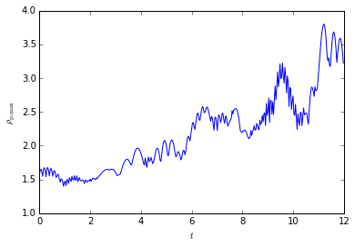

```python
fig, ax = plt.subplots(1,1)
ax.plot(ts.t, ts.rhopmax)
ax.set_xlabel(r'$t$')
ax.set_ylabel(r'$\rho_\mathrm{p,max}$')
```

# See available content of timeseries

The timeseries object stores all you available quantity timeseries. To get an overview use ts. to the via autocomplete or use

```python
print([s for s in dir(ts) if not s.startswith('__')])
```

[output not shown]

# Plot all density timeseries in two lines

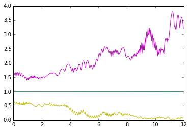

```python
for q in dir(ts):
    if q.startswith('rho'): plt.plot(ts.t, getattr(ts, q))
```